# Diabetes Risk Prediction

2023-07-02

#### Lachin Naghashyar - 98110179

```r
library(data.table)
library(ggplot2)
```

```r
d1 = fread('C:/Users/acer/Desktop/New folder/diabetes_012_health_indicators_BRFSS2015.csv', encoding = 'UTF-8')
d2 = fread('C:/Users/acer/Desktop/New folder/diabetes_binary_5050split_health_indicators_BRFSS2015.csv', encoding = 'UTF-8')
d3 = fread('C:/Users/acer/Desktop/New folder/diabetes_binary_health_indicators_BRFSS2015.csv', encoding = 'UTF-8')
```

### Q1: Investigating the contributition of the predictors as risk factors for diabetes prediction

#### BMI

```r
d1$Diabetes_012 = as.factor(d1$Diabetes_012)
d2$Diabetes_binary = as.factor(d2$Diabetes_binary)
d3$Diabetes_binary = as.factor(d3$Diabetes_binary)
```

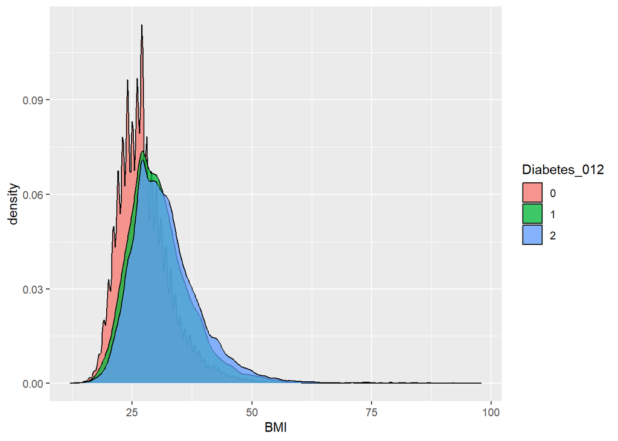

```r
ggplot(d1, aes(BMI, fill=Diabetes_012)) + geom_density(alpha=0.75)
```

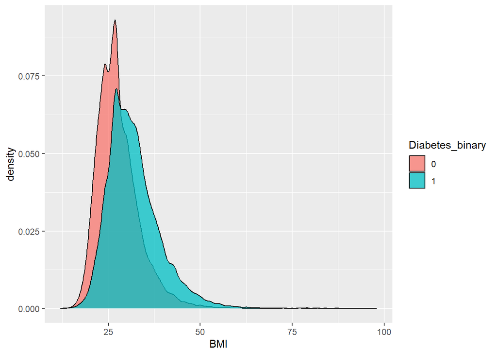

```r
ggplot(d2, aes(BMI, fill=Diabetes_binary)) + geom_density(alpha=0.75)
```

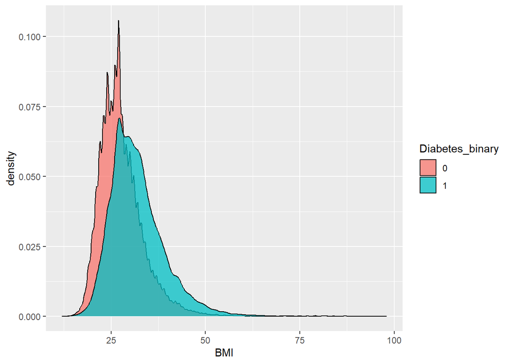

```r
ggplot(d3, aes(BMI, fill=Diabetes_binary)) + geom_density(alpha=0.75)
```

It seems that individuals with lower scores of BMI are less prone to Diabetes and the ones with prediabetes or diabetes are much similar in BMI scores. We can also compare their histograms too:

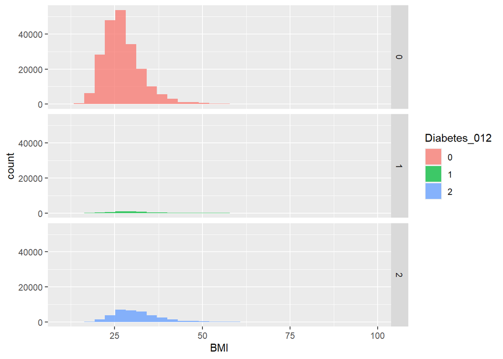

```r
ggplot(d1, aes(BMI, fill=Diabetes_012)) + geom_histogram(alpha=0.75) + facet_grid(Diabetes_012 ~ .)
```

We know that a histogram shows the counts of values in each range, while a density plot shows the proportion of values in each range. This way, since the data is not balanced, we can use density or histogram with ‘free_y’ to compare them correctly.

Overall, it seems that the BMI distribution is the most frequent between 22 and 30 and is one of the important risk factors for developing diabetes. Higher BMI correlates with the probability of occurrence of the disease.

#### Age:

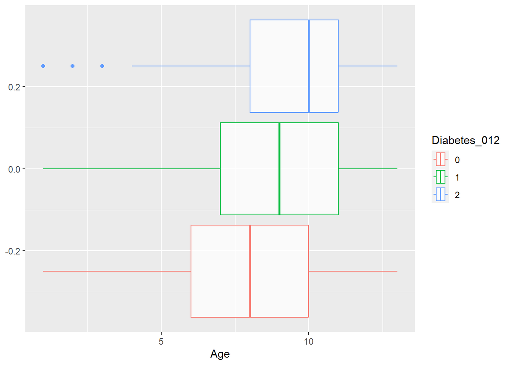

```r
ggplot(d1, aes(Age, group = Diabetes_012, color = Diabetes_012)) + geom_boxplot(alpha = 0.75)
```

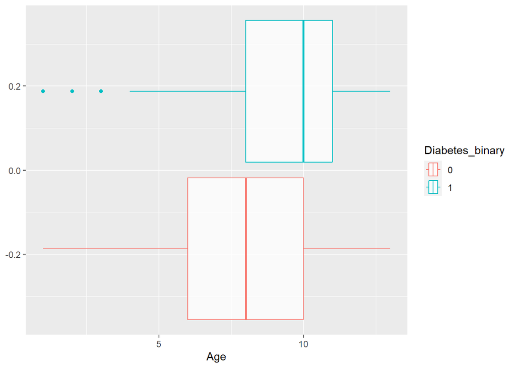

```r
ggplot(d2, aes(Age, group = Diabetes_binary, color = Diabetes_binary)) + geom_boxplot(alpha = 0.75)
```

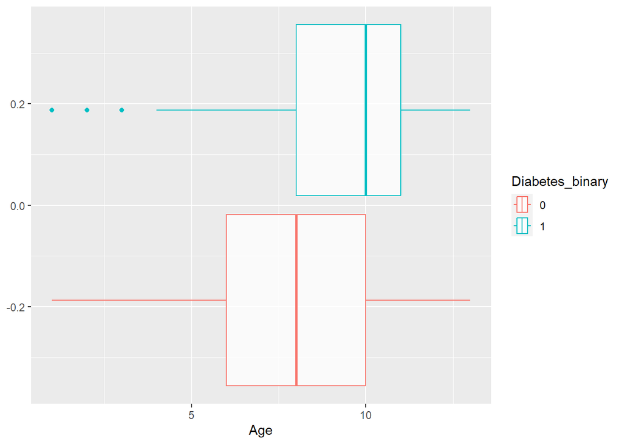

```r
ggplot(d3, aes(Age, group = Diabetes_binary, color = Diabetes_binary)) + geom_boxplot(alpha = 0.75)
```

This correlates with our prior knowledge that advanced age is a major risk factor for diabetes and prediabetes. Therefore, the elderly has a higher prevalence of diabetes and prediabetes than the young and middle-aged.

#### NoDocbcCost

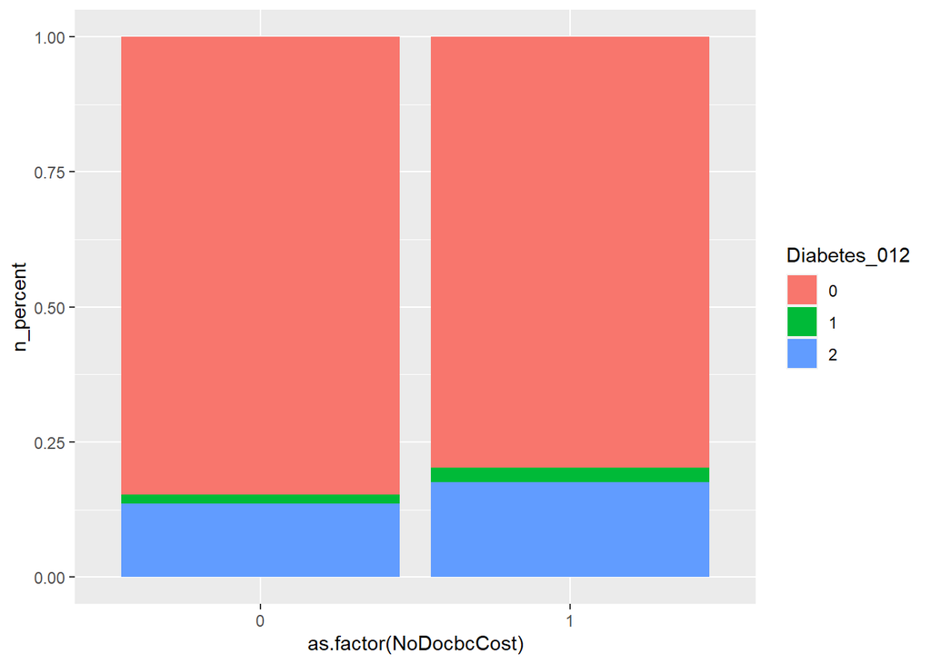

```r
d1$one = 1
ds = d1[, .(n = sum(one)), .(Diabetes_012, NoDocbcCost)]
ds[, n_total := sum(n), .(NoDocbcCost)]
ds[, n_percent := n/n_total]
ggplot(ds, aes(as.factor(NoDocbcCost), n_percent, fill = Diabetes_012)) + geom_bar(stat = 'identity',)
```

It seems that prediabetes and diabetes are related to this factor (Was there a time in the past 12 months when you needed to see a doctor but could not because of cost? 0 = no 1 = yes) which also makes sense.

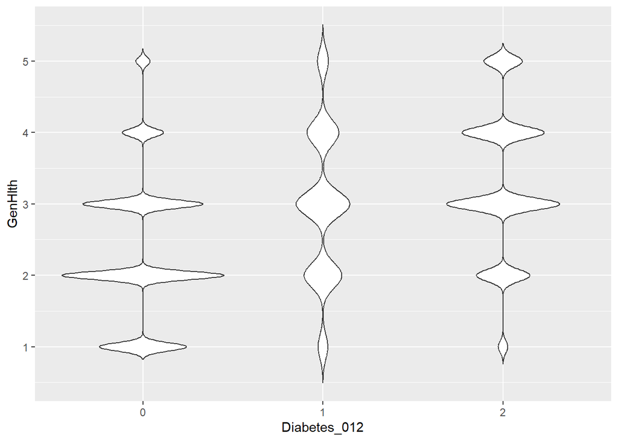

```r
ggplot(d1, aes(x=Diabetes_012, y=GenHlth)) +
  geom_violin(trim=FALSE)
```

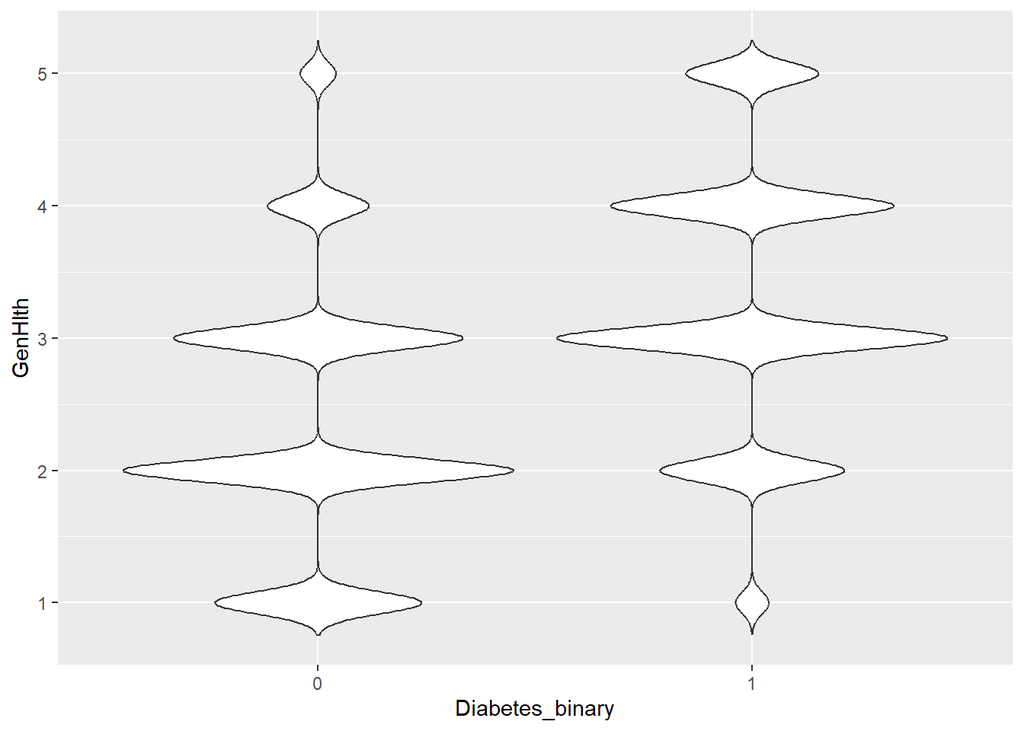

```r
ggplot(d2, aes(x=Diabetes_binary, y=GenHlth)) +
  geom_violin(trim=FALSE)
```

#### Education

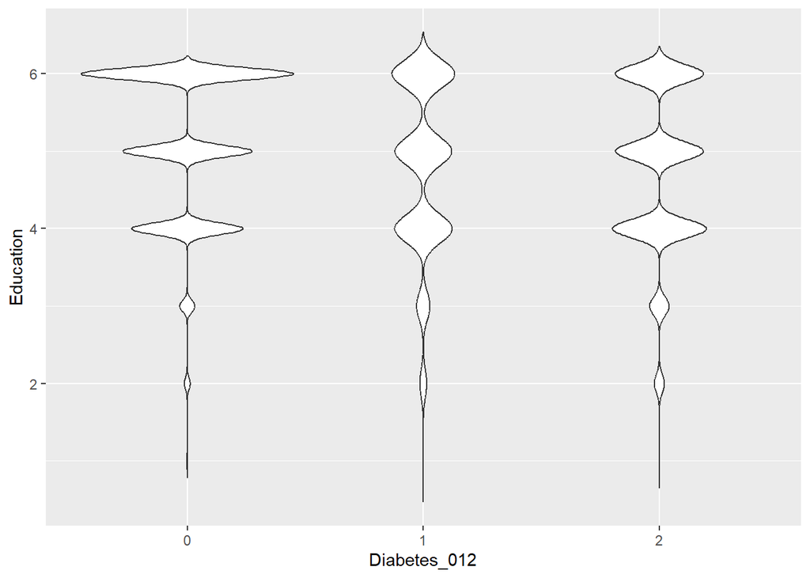

```r
ggplot(d1, aes(x=Diabetes_012, y=Education)) + geom_violin(trim=FALSE)
```

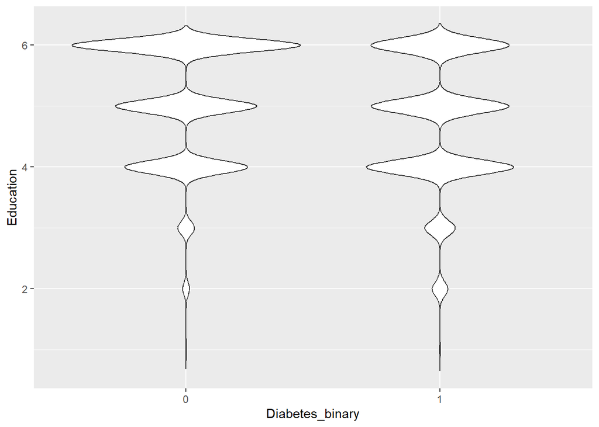

```r
ggplot(d2, aes(x=Diabetes_binary, y=Education)) + geom_violin(trim=FALSE)
```

The overall form and distribution of the recommendations for education compared to the diabetes status of patients (quartiles relatively close to each other).

#### Income

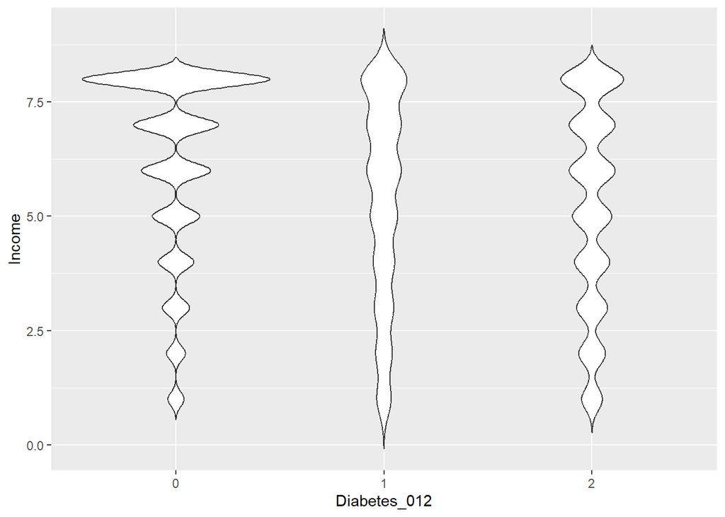

```r
ggplot(d1, aes(x=Diabetes_012, y=Income)) + geom_violin(trim=FALSE)
```

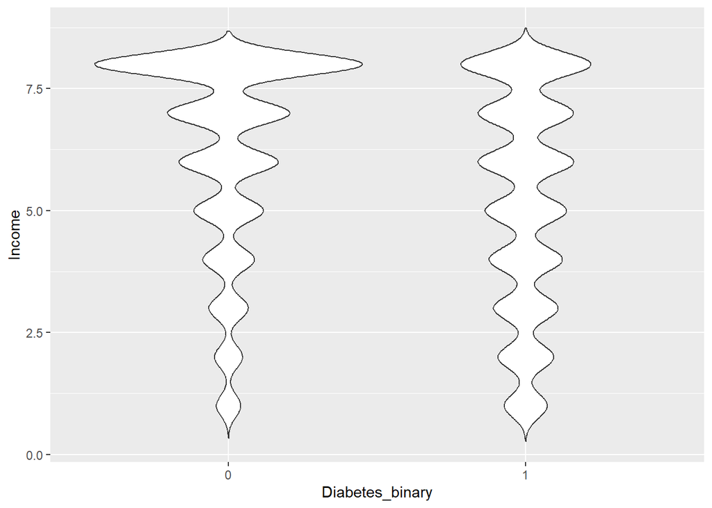

```r
ggplot(d2, aes(x=Diabetes_binary, Income)) + geom_violin(trim=FALSE)
```

### Q2: Feature Selection

#### Data Preprocessing

From here on, we are goining to use the second file as our data to proceed and feed in to our models. We could have used SMOTE or ADASYN to produce more synthetic data for minority class examples. However, in the second one the data is balanced and there are equal number of examples in both classes.

#### Random Forest Method

Random forest can be very effective to find a set of predictors that best explains the variance in the response variable.

[output not shown]

```r
d2 = fread('C:/Users/acer/Desktop/New folder/diabetes_binary_5050split_health_indicators_BRFSS2015.csv', encoding = 'UTF-8')
Diabetes_binary = as.factor(d2$Diabetes_binary)
```

#### Step-wise Regression

If you have large number of predictors (> 15), split the inputData in chunks of 10 predictors with each chunk holding the responseVar.

```r
base.mod <- lm(Diabetes_binary ~ 1 , data= d2)  # base intercept only model
all.mod <- lm(Diabetes_binary ~ . , data= d2) # full model with all predictors
stepMod <- step(base.mod, scope = list(lower = base.mod, upper = all.mod), direction = "both", trace = 0, steps = 1000)  # perform step-wise algorithm, both backward and forward
shortlistedVars <- names(unlist(stepMod[[1]])) # get the shortlisted variable.
shortlistedVars <- shortlistedVars[!shortlistedVars %in% "(Intercept)"]  # remove intercept
print(shortlistedVars)
```

```
##  [1] "GenHlth"              "HighBP"               "BMI"
##  [4] "Age"                  "HighChol"             "HvyAlcoholConsump"
##  [7] "CholCheck"            "Income"               "Sex"
## [10] "HeartDiseaseorAttack" "PhysHlth"             "DiffWalk"
## [13] "Education"            "MentHlth"             "Stroke"
## [16] "Veggies"              "PhysActivity"         "AnyHealthcare"
## [19] "Fruits"
```

The output could includes levels within categorical variables, since ‘stepwise’ is a linear regression based technique, as seen above. As expected, the features such as GenHlth, HighBp, BMI, Age, HighChol and etc, have higher importance. (Due to the nature of step-wise feature selection approach, we are not expecting the best model, but somehow a model and a result close to the optimal one)

#### MARS

The earth package implements variable importance based on Generalized cross validation (GCV), number of subset models the variable occurs (nsubsets) and residual sum of squares (RSS).

```r
library(earth)
```

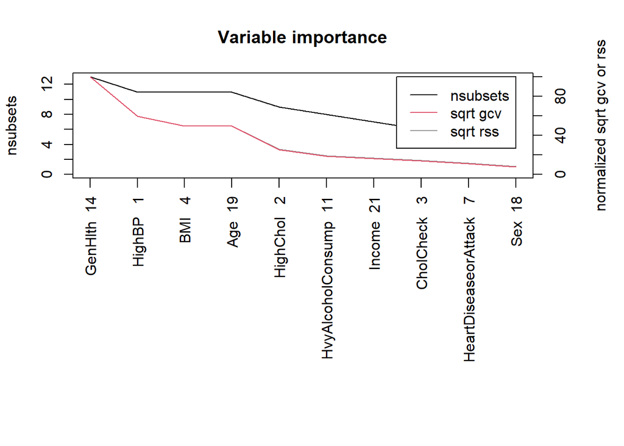

```r
marsModel <- earth(as.factor(Diabetes_binary) ~ ., data=d2) # build model
ev <- evimp (marsModel) # estimate variable importance
plot(ev)
```

### Machine Learning Models

Before proceeding forward, we have to specify the models we are going to use in this problem. Since it is a classification problem, we are going to make use of these five models: 1)Decision Tree (DT), 2)Random Forest (RF), 3)KNN, 4)Logistic Regression 5)Naive Bayes

#### Logistic Regression

Logistic regression is a classification model rather than regression model. Logistic regression is a simple and more efficient method for binary and linear classification problems. It is a classification model, which is very easy to realize and achieves very good performance with linearly separable classes. It is an extensively employed algorithm for classification in industry. LR is most commonly used for the classification of binary classes. It internally uses the sigmoid function to learn the linear relationships between variables. The solvers and penalty can be changed to see visible differences in the classification. In this study, a random state of 0 was used.

#### Naive Bayes

Naive Bayes is a machine learning algorithm that is based on Bayes theorem. It makes an assumption that all attributes are independent so it does not produce good results when the dataset size is large and it has a lot of features.

### Metrics used for Evaluation of results

After training, the classifiers are evaluated using several metrics based on the confusion matrix. The metrics include accuracy, sensitivity, specificity, ROC-AUC curve, and Precision–Recall curve. Confusion matrices and the formulae used to calculate these metrics are defined below.

#### Accuracy

The accuracy of a test is its power to accurately distinguish between sick and healthy individuals. When calculating the accuracy of the diagnostic test, the rate of true positive and true negative is calculated for all patients and healthy individuals. The accuracy value takes a value between 0 and 1.

$Accuracy = \frac{𝑇𝑃 + 𝑇𝑁}{𝑇𝑃 + 𝑇𝑁 + 𝐹𝑃 + 𝐹P}$

However, accuracy is not an adequate performance measure for assessing the power of the whole model on its own and is not truly predictive. Precision, Recall, and Specificity are used alongside accuracy to provide a more balanced evaluation approach.

#### Hamming Loss

The Hamming loss is the proportion of incorrect labels to total labels. Hammering loss is determined in multi-class classification as the hamming distance between ‘actual’ and ’predictions.’ Hamming loss penalizes only the individual labels in multi-label categorization. The lower the loss, the better the model performance.

$ Hamming Loss = 1 - Accuracy $

#### Precision

In disease detection, predicted false positives can lead to misdiagnosis and cause wastage of healthcare resources, and improving the precision of diagnostic models can help to improve this problem. Precision quantifies the number of correctly forecast positive observations: This is accomplished by counting the samples that were correctly predicted as positive (TP) and dividing them by the total number of positive predictions, correct or incorrect (TP, FP).

$Precision = \frac{TP}{TP + FP}$

#### Recall

Recall or sensitivity, like precision, aims to figure out the proportion of true positives that were accurately detected. It accomplishes this by dividing the correctly predicted positive samples (TP) by the total number of positives, either correctly or incorrectly predicted as positive (TP, FN). Recall measures the number of correct positive predictions out of all possible positive predictions made.

$Recall = \frac{TP}{TP + FN}$

#### Specificity

Specificity measures the percentage of actual negatives that were accurately identified. This is accomplished by dividing the number of correctly predicted negative samples by the total number of samples that were either correctly or mistakenly forecasted as negative (TN, FP).

$Specificity = \frac{TN}{FP + TN}$

A detection system with a high specificity contributes to the issue of over-medicalization, as diagnosing a patient without diabetes as a person with diabetes can cause anxiety and unnecessary follow-up procedures

#### F1-Score

Depending on the problem being attempted to solve, in most cases a higher priority can be assigned to maximize precision or recall. However, there is a simpler statistic that takes into account both precision and recall, and attempts are made to maximize this number to improve the model. The F1 score is essentially a statistic that is the harmonic mean of precision and recall. The formula for the F1 score is entirely dependent on precision and recall.

$F1Score = 2 \times \frac{Precision \times Recall}{Precision + Recall}$

It can have a maximum value of 1, signifying flawless precision and recall, and a minimum value of 0 if either precision or recall is zero.

#### AUC

The Precision–Recall curve is perfect when it is right-angle or perpendicular and maximized the area under the curve which is also referred to as AUC.

### Q3 & Q4

Yes, as we know, feature subset selection is the process of identifying and removing as much of the irrelevant and redundant information as possible. This reduces the dimensionality of the data and allows learning algorithms to operate faster and more effectively. With the methods used in the previous part, we are able to choose the most important features to use in our models.

I decided to choose the following variables : GenHlth, HighBP, BMI, Age, HighChol, HvyAlcoholConsump and Income.

```r
suppressWarnings({
 library(plyr)
 library(readr)
 library(dplyr)
 library(caret)
})
d2 = fread('C:/Users/acer/Desktop/New folder/diabetes_binary_5050split_health_indicators_BRFSS2015.csv', encoding = 'UTF-8')
d2m = d2[,c("Diabetes_binary","GenHlth", "HighBP", "BMI", "Age", "HighChol", "HvyAlcoholConsump", "Income")]
d2m
```

```
##        Diabetes_binary GenHlth HighBP BMI Age HighChol HvyAlcoholConsump Income
##     1:               0       3      1  26   4        0                 0      8
##     2:               0       3      1  26  12        1                 0      8
##     3:               0       1      0  26  13        0                 0      8
##     4:               0       3      1  28  11        1                 0      8
##     5:               0       2      0  29   8        0                 0      8
##    ---
## 70688:               1       4      0  37   6        1                 0      1
## 70689:               1       2      0  29  10        1                 0      6
## 70690:               1       5      1  25  13        1                 0      4
## 70691:               1       4      1  18  11        1                 0      4
## 70692:               1       2      1  25   9        1                 0      2
```

```r
glimpse(d2m)
```

```
## Rows: 70,692
## Columns: 8
## $ Diabetes_binary   <dbl> 0, 0, 0, 0, 0, 0, 0, 0, 0, 0, 0, 0, 0, 0, 0, 0, 0, 0…
## $ GenHlth           <dbl> 3, 3, 1, 3, 2, 2, 1, 4, 3, 3, 3, 1, 2, 3, 1, 3, 2, 1…
## $ HighBP            <dbl> 1, 1, 0, 1, 0, 0, 0, 0, 0, 0, 1, 0, 1, 1, 0, 0, 0, 0…
## $ BMI               <dbl> 26, 26, 26, 28, 29, 18, 26, 31, 32, 27, 24, 21, 27, …
## $ Age               <dbl> 4, 12, 13, 11, 8, 1, 13, 6, 3, 6, 12, 4, 7, 10, 10, …
## $ HighChol          <dbl> 0, 1, 0, 1, 0, 0, 1, 0, 0, 0, 1, 0, 1, 0, 1, 0, 0, 0…
## $ HvyAlcoholConsump <dbl> 0, 0, 0, 0, 0, 0, 1, 0, 0, 0, 0, 0, 0, 0, 0, 0, 0, 0…
## $ Income            <dbl> 8, 8, 8, 8, 8, 7, 6, 3, 8, 4, 6, 8, 8, 6, 1, 6, 7, 7…
```

#### Exploratory Data Analysis

```r
# Checking for missing values
sum(is.na(d2m))
```

```
## [1] 0
```

I guess all of the predictors except BMI are considered to be categorized in different levels. For exmaple it is stated in the documents that Age is partitioned into 13 levels. So let’s factorize this variables

```r
# We will convert these into factor variables using the line of code below.
d2m[,1:8] <- lapply(d2m[,1:8] , as.factor)
d2m[,4] <- lapply(d2m[,4] , as.numeric)
glimpse(d2m)
```

```
## Rows: 70,692
## Columns: 8
## $ Diabetes_binary   <fct> 0, 0, 0, 0, 0, 0, 0, 0, 0, 0, 0, 0, 0, 0, 0, 0, 0, 0…
## $ GenHlth           <fct> 3, 3, 1, 3, 2, 2, 1, 4, 3, 3, 3, 1, 2, 3, 1, 3, 2, 1…
## $ HighBP            <fct> 1, 1, 0, 1, 0, 0, 0, 0, 0, 0, 1, 0, 1, 1, 0, 0, 0, 0…
## $ BMI               <dbl> 15, 15, 15, 17, 18, 7, 15, 20, 21, 16, 13, 10, 16, 4…
## $ Age               <fct> 4, 12, 13, 11, 8, 1, 13, 6, 3, 6, 12, 4, 7, 10, 10, …
## $ HighChol          <fct> 0, 1, 0, 1, 0, 0, 1, 0, 0, 0, 1, 0, 1, 0, 1, 0, 0, 0…
## $ HvyAlcoholConsump <fct> 0, 0, 0, 0, 0, 0, 1, 0, 0, 0, 0, 0, 0, 0, 0, 0, 0, 0…
## $ Income            <fct> 8, 8, 8, 8, 8, 7, 6, 3, 8, 4, 6, 8, 8, 6, 1, 6, 7, 7…
```

#### Create a Validation Dataset

We need to know that the model we created is any good. Later, we will use statistical methods to estimate the accuracy of the models that we create on unseen data. We also want a more concrete estimate of the accuracy of the best model on unseen data by evaluating it on actual unseen data. That is, we are going to hold back some data that the algorithms will not get to see and we will use this data to get a second and independent idea of how accurate the best model might actually be.

```r
# create a list of 80% of the rows in the original dataset we can use for training
validation_index <- createDataPartition(d2m$Diabetes_binary, p=0.80, list=FALSE)
# select 20% of the data for validation
validation <- d2m[-validation_index,]
# use the remaining 80% of data to training and testing the models
d2m <- d2m[validation_index,]
```

#### Building Models

We reset the random number seed before reach run to ensure that the evaluation of each algorithm is performed using exactly the same data splits. It ensures the results are directly comparable.

Let’s build our five models:

```r
cv_folds <- createFolds(d2m$Diabetes_binary, k = 5, returnTrain = TRUE)
tuneGrid <- expand.grid(.mtry = c(1 : 10))

ctrl <- trainControl(method = "cv",
                     number = 5,
                     search = 'grid',
                     classProbs = TRUE,
                     savePredictions = "final",
                     index = cv_folds,
                     summaryFunction = twoClassSummary) #in most cases a better summary for two class problems

metric = "ROC"
```

##### Decision Tree

```r
set.seed(7)
fit.tree <- train(make.names(Diabetes_binary)~., data=d2m, method="rpart", metric=metric, trControl=ctrl)
fit.tree
```

```
## CART
##
## 56554 samples
##     7 predictor
##     2 classes: 'X0', 'X1'
##
## No pre-processing
## Resampling: Cross-Validated (5 fold)
## Summary of sample sizes: 45243, 45244, 45242, 45244, 45243
## Resampling results across tuning parameters:
##
##   cp           ROC        Sens       Spec
##   0.009265481  0.7312956  0.7056625  0.7020898
##   0.011192842  0.6990915  0.6571087  0.7290359
##   0.379601797  0.6127188  0.5754200  0.6500176
##
## ROC was used to select the optimal model using the largest value.
## The final value used for the model was cp = 0.009265481.
```

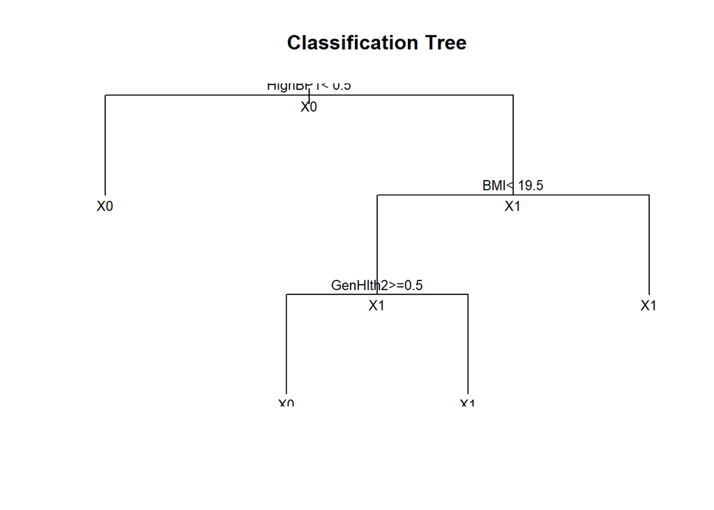

```r
# plot the model
plot(fit.tree$finalModel, uniform=TRUE,
     main="Classification Tree")
text(fit.tree$finalModel, all=TRUE, cex=.8)
```

##### Random Forest

```r
set.seed(7)
fit.rf <- train(make.names(Diabetes_binary)~., data=d2m, method="rf", metric=metric, trControl=ctrl, ntree = 80, nodesize = c(1, 5))
```

```r
fit.rf
```

```
## Random Forest
##
## 56554 samples
##     7 predictor
##     2 classes: 'X0', 'X1'
##
## No pre-processing
## Resampling: Cross-Validated (5 fold)
## Summary of sample sizes: 45243, 45244, 45242, 45244, 45243
## Resampling results across tuning parameters:
##
##   mtry  ROC        Sens       Spec
##    2    0.8109909  0.7022310  0.7786186
##   14    0.7857385  0.6930722  0.7366056
##   27    0.7690059  0.6954770  0.7019837
##
## ROC was used to select the optimal model using the largest value.
## The final value used for the model was mtry = 2.
```

##### KNN

```r
set.seed(7)
fit.knn <- train(make.names(Diabetes_binary)~., data=d2m, method="knn", metric=metric, trControl=ctrl)
```

```r
fit.knn
```

```
## k-Nearest Neighbors
##
## 56554 samples
##     7 predictor
##     2 classes: 'X0', 'X1'
##
## No pre-processing
## Resampling: Cross-Validated (5 fold)
## Summary of sample sizes: 45243, 45244, 45242, 45244, 45243
## Resampling results across tuning parameters:
##
##   k  ROC        Sens       Spec
##   5  0.7909537  0.6843725  0.7640130
##   7  0.7978763  0.6851856  0.7714748
##   9  0.8010026  0.6874491  0.7741979
##
## ROC was used to select the optimal model using the largest value.
## The final value used for the model was k = 9.
```

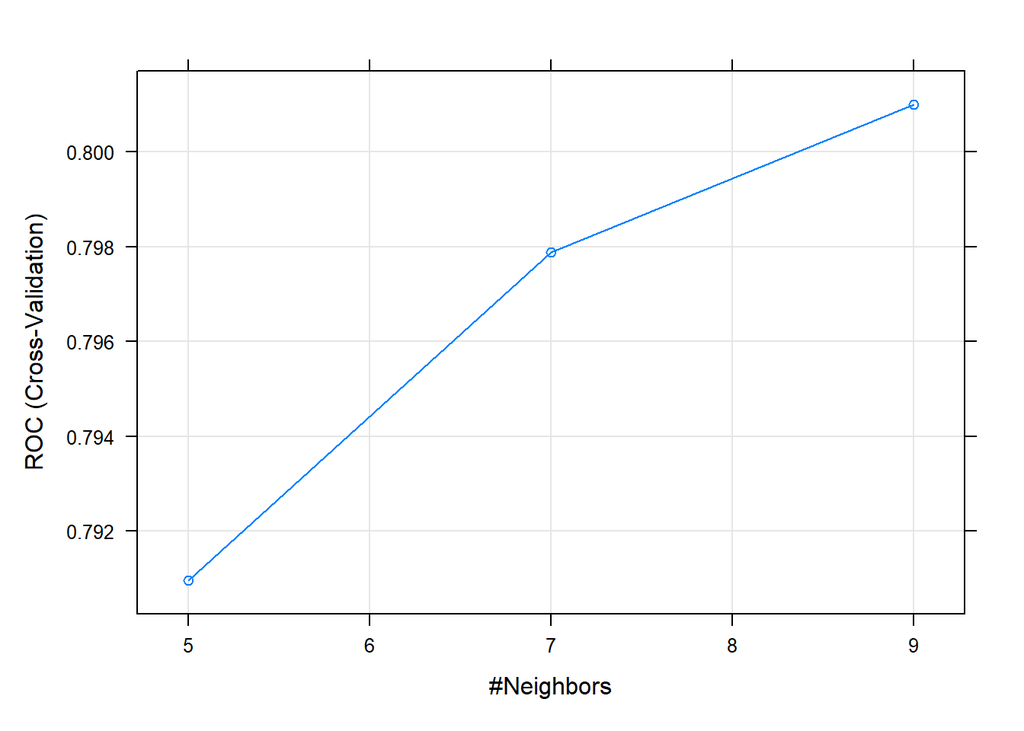

```r
plot(fit.knn)
```

##### logistic regression

```r
set.seed(7)
fit.lr <- train(make.names(Diabetes_binary)~., data=d2m, method="glm", metric=metric, trControl=ctrl)
```

```r
fit.lr
```

```
## Generalized Linear Model
##
## 56554 samples
##     7 predictor
##     2 classes: 'X0', 'X1'
##
## No pre-processing
## Resampling: Cross-Validated (5 fold)
## Summary of sample sizes: 45243, 45244, 45242, 45244, 45243
## Resampling results:
##
##   ROC        Sens       Spec
##   0.8231551  0.7180037  0.77441
```

##### Naive Bayes

```r
suppressWarnings({
 set.seed(7)
 fit.nb <- train(make.names(Diabetes_binary)~., data=d2m, method="nb", metric=metric, trControl=ctrl)
 fit.nb
})
```

Naive Bayes

56554 samples 7 predictor 2 classes: ‘X0’, ‘X1’

Tuning parameter ‘fL’ was held constant at a value of 0 Tuning parameter ‘adjust’ was held constant at a value of 1 ROC was used to select the optimal model using the largest value. The final values used for the model were fL = 0, usekernel = TRUE and adjust = 1.

#### Model Selection

We used ROC as our metric and now we can use it to compare the models to each other and select the best one amongst others.

```r
# summarize accuracy of models
results <- resamples(list(DT=fit.tree, RF=fit.rf, knn=fit.knn, LR=fit.lr, NB=fit.nb))
summary(results)
```

```
##
## Call:
## summary.resamples(object = results)
##
## Models: DT, RF, knn, LR, NB
## Number of resamples: 5
##
## ROC
##          Min.   1st Qu.    Median      Mean   3rd Qu.      Max. NA's
## DT  0.7101214 0.7110446 0.7284852 0.7312956 0.7528558 0.7539712    0
## RF  0.8055795 0.8063257 0.8118559 0.8109909 0.8126215 0.8185719    0
## knn 0.7937872 0.7971353 0.8017395 0.8010026 0.8060649 0.8062859    0
## LR  0.8179022 0.8189325 0.8247438 0.8231551 0.8252372 0.8289599    0
## NB  0.8051901 0.8096667 0.8125053 0.8129424 0.8180991 0.8192507    0
##
## Sens
##          Min.   1st Qu.    Median      Mean   3rd Qu.      Max. NA's
## DT  0.6925389 0.6996110 0.7006189 0.7056625 0.7083996 0.7271441    0
## RF  0.6891247 0.7006189 0.7020336 0.7022310 0.7086280 0.7107496    0
## knn 0.6797524 0.6838196 0.6877652 0.6874491 0.6895332 0.6963749    0
## LR  0.7112290 0.7144120 0.7183024 0.7180037 0.7229491 0.7231259    0
## NB  0.5097242 0.5145889 0.5197171 0.5205290 0.5257294 0.5328854    0
##
## Spec
##          Min.   1st Qu.    Median      Mean   3rd Qu.      Max. NA's
## DT  0.6789250 0.6822281 0.6908930 0.7020898 0.7273210 0.7310820    0
## RF  0.7687003 0.7782493 0.7782885 0.7786186 0.7800566 0.7877984    0
## knn 0.7683876 0.7695844 0.7711760 0.7741979 0.7766578 0.7851839    0
## LR  0.7671088 0.7722772 0.7740053 0.7744100 0.7748895 0.7837694    0
## NB  0.9004421 0.9039788 0.9057471 0.9050463 0.9073550 0.9077086    0
```

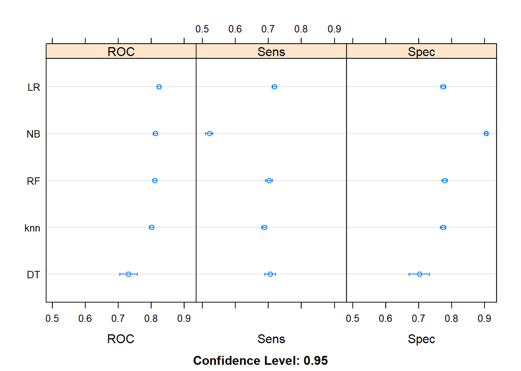

```r
dotplot(results)
```

We can also compute their accuracy or other metrics. As we have seen we can compare their cp scores or use CV to select the best model.

```r
suppressWarnings({
control <- trainControl(method="cv", number=5)
metric <- "Accuracy"
set.seed(7)
fit.tree <- train(Diabetes_binary~., data=d2m, method="rpart", metric=metric, trControl=control)
set.seed(7)
fit.rf <- train(Diabetes_binary~., data=d2m, method="rf", metric=metric, trControl=control, ntree = 60, nodesize = c(1, 5))
set.seed(7)
fit.knn <- train(Diabetes_binary~., data=d2m, method="knn", metric=metric, trControl=control)
set.seed(7)
fit.lr <- train(Diabetes_binary~., data=d2m, method="glm", metric=metric, trControl=control)
set.seed(7)
fit.nb <- train(Diabetes_binary~., data=d2m, method="nb", metric=metric, trControl=control)
})
```

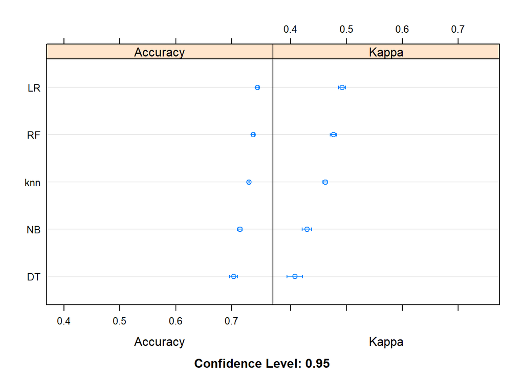

```r
# compare accuracy of models
results <- resamples(list(DT=fit.tree, RF=fit.rf, knn=fit.knn, LR=fit.lr, NB=fit.nb))
dotplot(results)
```

```r
fit.tree
```

```
## CART
##
## 56554 samples
##     7 predictor
##     2 classes: '0', '1'
##
## No pre-processing
## Resampling: Cross-Validated (5 fold)
## Summary of sample sizes: 45244, 45243, 45243, 45244, 45242
## Resampling results across tuning parameters:
##
##   cp           Accuracy   Kappa
##   0.009141705  0.7036640  0.4073288
##   0.011281253  0.6926475  0.3852973
##   0.377197015  0.5744198  0.1488589
##
## Accuracy was used to select the optimal model using the largest value.
## The final value used for the model was cp = 0.009141705.
```

```r
fit.rf
```

```
## Random Forest
##
## 56554 samples
##     7 predictor
##     2 classes: '0', '1'
##
## No pre-processing
## Resampling: Cross-Validated (5 fold)
## Summary of sample sizes: 45244, 45243, 45243, 45244, 45242
## Resampling results across tuning parameters:
##
##   mtry  Accuracy   Kappa
##    2    0.7382678  0.4765355
##   14    0.7144323  0.4288648
##   27    0.6961488  0.3922979
##
## Accuracy was used to select the optimal model using the largest value.
## The final value used for the model was mtry = 2.
```

```r
fit.knn
```

```
## k-Nearest Neighbors
##
## 56554 samples
##     7 predictor
##     2 classes: '0', '1'
##
## No pre-processing
## Resampling: Cross-Validated (5 fold)
## Summary of sample sizes: 45244, 45243, 45243, 45244, 45242
## Resampling results across tuning parameters:
##
##   k  Accuracy   Kappa
##   5  0.7219472  0.4438946
##   7  0.7276938  0.4553879
##   9  0.7309120  0.4618242
##
## Accuracy was used to select the optimal model using the largest value.
## The final value used for the model was k = 9.
```

```r
fit.lr
```

```
## Generalized Linear Model
##
## 56554 samples
##     7 predictor
##     2 classes: '0', '1'
##
## No pre-processing
## Resampling: Cross-Validated (5 fold)
## Summary of sample sizes: 45244, 45243, 45243, 45244, 45242
## Resampling results:
##
##   Accuracy   Kappa
##   0.7458711  0.4917424
```

```r
fit.nb
```

```
## Naive Bayes
##
## 56554 samples
##     7 predictor
##     2 classes: '0', '1'
##
## No pre-processing
## Resampling: Cross-Validated (5 fold)
## Summary of sample sizes: 45244, 45243, 45243, 45244, 45242
## Resampling results across tuning parameters:
##
##   usekernel  Accuracy   Kappa
##   FALSE      0.6965732  0.3931466
##    TRUE      0.7145206  0.4290414
##
## Tuning parameter 'fL' was held constant at a value of 0
## Tuning
##  parameter 'adjust' was held constant at a value of 1
## Accuracy was used to select the optimal model using the largest value.
## The final values used for the model were fL = 0, usekernel = TRUE and adjust
##  = 1.
```

```r
predictions <- predict(fit.lr, validation)
confusionMatrix(as.factor(predictions), validation$Diabetes_binary)
```

```
## Confusion Matrix and Statistics
##
##           Reference
## Prediction    0    1
##          0 5066 1592
##          1 2003 5477
##
##                Accuracy : 0.7457
##                  95% CI : (0.7385, 0.7529)
##     No Information Rate : 0.5
##     P-Value [Acc > NIR] : < 2.2e-16
##
##                   Kappa : 0.4914
##
##  Mcnemar's Test P-Value : 8.026e-12
##
##             Sensitivity : 0.7167
##             Specificity : 0.7748
##          Pos Pred Value : 0.7609
##          Neg Pred Value : 0.7322
##              Prevalence : 0.5000
##          Detection Rate : 0.3583
##    Detection Prevalence : 0.4709
##       Balanced Accuracy : 0.7457
##
##        'Positive' Class : 0
##
```

Glm (or LR) and RF have similar results and glm is slightly better. We can proceed with both or if we are forced to choose one, then LR seems like a slightly better option.

#### Feature Selection with the Caret R Package

I saw another approach here https://machinelearningmastery.com/feature-selection-with-the-caret-r-package/ wich also seems pretty straight forward. However, after adjusting it for our problem, it takes too long to run and see the results (I even tried some packages to parallelize to procedure but again it takes too long). So I just included some parts of it here.

Selecting the right features in your data can mean the difference between mediocre performance with long training times and great performance with short training times.

The caret R package provides tools to automatically report on the relevance and importance of attributes in your data and even select the most important features for you.

##### Remove Redundant Features

Data can contain attributes that are highly correlated with each other. Many methods perform better if highly correlated attributes are removed. Generally, you want to remove attributes with an absolute correlation of 0.75 or higher.

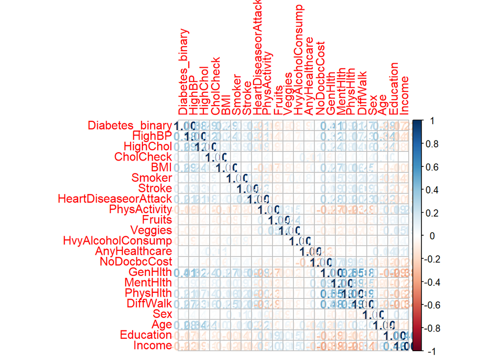

```r
library(corrplot)
d2 = fread('C:/Users/acer/Desktop/New folder/diabetes_binary_5050split_health_indicators_BRFSS2015.csv', encoding = 'UTF-8')
M = cor(d2)
corrplot(M, method = 'number') # colorful number
```

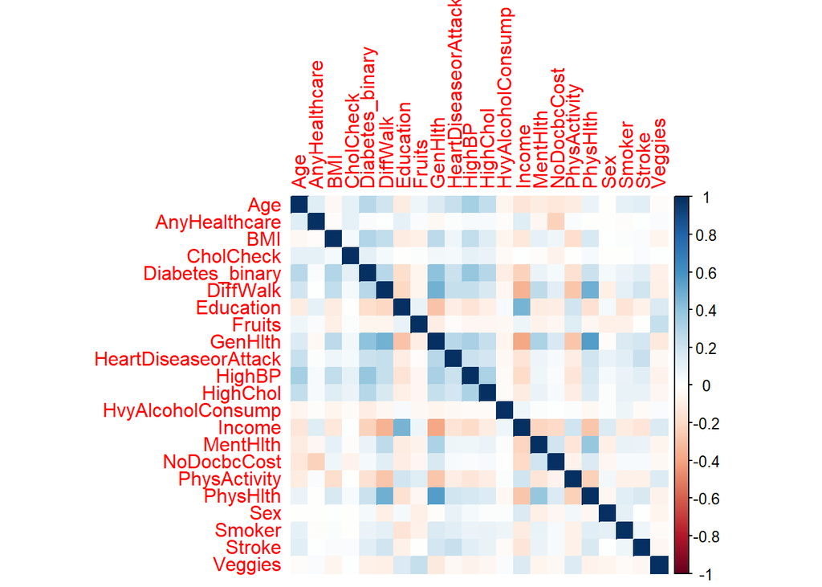

```r
corrplot(M, method = 'color', order = 'alphabet')
```

```r
# ensure results are repeatable
set.seed(7)
# load the library
library(mlbench)
library(caret)
# calculate correlation matrix
correlationMatrix <- cor(d2[,1:21])
# find attributes that are highly corrected (ideally >0.75)
highlyCorrelated <- findCorrelation(correlationMatrix, cutoff=0.5)
# print indexes of highly correlated attributes
print(highlyCorrelated)
```

```
## [1] 15
```

```r
# library(parallel)
# library(doParallel)
# cluster <- makeCluster(detectCores()[1] - 1) # convention to leave 1 core for OS
# registerDoParallel(cluster)
```

##### Rank Features By Importance

The importance of features can be estimated from data by building a model. Some methods like decision trees have a built in mechanism to report on variable importance. For other algorithms, the importance can be estimated using a ROC curve analysis conducted for each attribute.

```r
# prepare training scheme
control <- trainControl(method="cv", number=4, allowParallel = TRUE)
# train the model
model <- train(as.factor(Diabetes_binary)~., data=d2, method="glm", preProcess="scale", trControl=control)
# estimate variable importance
importance <- varImp(model, scale=FALSE)
# summarize importance
print(importance)
```

```
## glm variable importance
##
##   only 20 most important variables shown (out of 21)
##
##                      Overall
## GenHlth              51.0712
## BMI                  48.0570
## Age                  38.9498
## HighBP               37.2549
## HighChol             31.1391
## CholCheck            16.7348
## HvyAlcoholConsump    15.3748
## Sex                  13.9559
## Income               11.3251
## HeartDiseaseorAttack  8.8862
## PhysHlth              6.9807
## DiffWalk              4.4445
## Stroke                3.9600
## Education             3.6019
## MentHlth              3.3941
## Veggies               2.6165
## Fruits                1.7613
## PhysActivity          1.5559
## AnyHealthcare         1.2894
## NoDocbcCost           0.5571
```

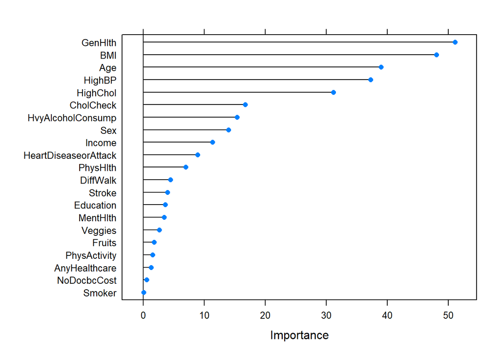

```r
# plot importance
plot(importance)
```

##### Feature Selection

Automatic feature selection methods can be used to build many models with different subsets of a dataset and identify those attributes that are and are not required to build an accurate model.

A popular automatic method for feature selection provided by the caret R package is called Recursive Feature Elimination or RFE.

A Random Forest algorithm is used on each iteration to evaluate the model. The algorithm is configured to explore all possible subsets of the attributes.

[figure not shown]

```r
# define the control using a random forest selection function
# control <- rfeControl(functions=rfFuncs, method="cv", number=3)
# run the RFE algorithm
# x = d2[,2:22]
# y = d2$Diabetes_binary
# results <- rfe(x, y,size=c(1:21), rfeControl=control)
# summarize the results
# print(results)
# list the chosen features
# predictors(results)
# plot the results
# plot(results, type=c("g", "o"))
```

It takes too long to run but will result in a model with optimal features.

```r
# parallel::stopCluster(cluster)
# registerDoSEQ()
```

Instead, we can again use another approach:

```r
library(tidyverse)
library(caret)
library(leaps)
```

The R function regsubsets() can be used to identify different best models of different sizes. You need to specify the option nvmax, which represents the maximum number of predictors to incorporate in the model.

```r
d2 = fread('C:/Users/acer/Desktop/New folder/diabetes_binary_5050split_health_indicators_BRFSS2015.csv', encoding = 'UTF-8')
models <- regsubsets(Diabetes_binary~., data = d2, nvmax = 21)
summary(models)
```

```
## Subset selection object
## Call: regsubsets.formula(Diabetes_binary ~ ., data = d2, nvmax = 21)
## 21 Variables  (and intercept)
##                      Forced in Forced out
## HighBP                   FALSE      FALSE
## HighChol                 FALSE      FALSE
## CholCheck                FALSE      FALSE
## BMI                      FALSE      FALSE
## Smoker                   FALSE      FALSE
## Stroke                   FALSE      FALSE
## HeartDiseaseorAttack     FALSE      FALSE
## PhysActivity             FALSE      FALSE
## Fruits                   FALSE      FALSE
## Veggies                  FALSE      FALSE
## HvyAlcoholConsump        FALSE      FALSE
```

[output cut: 100 more lines]

The best model, according to each of these metrics, can be extracted as follow:

```r
res.sum <- summary(models)
data.frame(
  Adj.R2 = which.max(res.sum$adjr2),
  CP = which.min(res.sum$cp),
  BIC = which.min(res.sum$bic)
)
```

```
##   Adj.R2 CP BIC
## 1     19 19  16
```

Using adj.R2 or Cp, we should go for a model with 19 variables. However, BIC suggests a model with 16 variables.

K-fold cross-validation The average cross-validation error is computed as the model prediction error.

```r
get_model_formula <- function(id, object, outcome){
  models <- summary(object)$which[id,-1]
  predictors <- names(which(models == TRUE))
  predictors <- paste(predictors, collapse = "+")
  as.formula(paste0(outcome, "~", predictors))
}
```

```r
get_cv_error <- function(model.formula, data){
  set.seed(1)
  train.control <- trainControl(method = "cv", number = 5)
  cv <- train(model.formula, data = data, method = "glm",
              trControl = train.control)
  cv$results$RMSE
}
```

```r
d2$Diabetes_binary = as.factor(d2$Diabetes_binary)
# Compute cross-validation error
model.ids <- 1:21
cv.errors <-  map(model.ids, get_model_formula, models, "Diabetes_binary") %>%
  map(get_cv_error, data = d2) %>%
  unlist()
#cv.errors
```

This code stipend was working currectly the last time, I don’t know what has happened now :(

```r
# Select the model that minimize the CV error
#which.min(cv.errors)
```

A better way of splitting the data is to not split it only into training and testing sets, but to also include a validation set. A typical ratio is 60% training, 20% validation, 20% testing.

So instead of just measuring the test error, you would also measure the validation error.

Validation is used mainly to tune hyperparameters - you don’t want to tune them on the training set because that can result in overfitting, nor do you want to tune them on your test set because that results in an overly optimistic estimation of generalization. Thus we keep a separate set of data for the purpose of validation, that is, for tuning the hyperparameters - the validation set.

The validation set is used during the training phase of the model to provide an unbiased evaluation of the model’s performance and to fine-tune the model’s parameters. The test set, on the other hand, is used after the model has been fully trained to assess the model’s performance on completely unseen data.

You can use these errors to identify what kind of problem you have if your model isn’t performing well.

```r
d2 = fread('C:/Users/acer/Desktop/New folder/diabetes_binary_5050split_health_indicators_BRFSS2015.csv', encoding = 'UTF-8')
# Define the partition (e.g. 75% of the data for training)
trainIndex <- createDataPartition(d2$Diabetes_binary, p = .75,
                                  list = FALSE,
                                  times = 1)

# Split the dataset using the defined partition
train_data <- d2[trainIndex, ,drop=FALSE]
tune_plus_val_data <- d2[-trainIndex, ,drop=FALSE]

# Define a new partition to split the remaining 25%
tune_plus_val_index <- createDataPartition(tune_plus_val_data$Diabetes_binary,
                                           p = .6,
                                           list = FALSE,
                                           times = 1)

# Split the remaining ~25% of the data: 40% (tune) and 60% (val)
tune_data <- tune_plus_val_data[-tune_plus_val_index, ,drop=FALSE]
val_data <- tune_plus_val_data[tune_plus_val_index, ,drop=FALSE]

# Outcome of this section is that the data (100%) is split into:
# training (~75%)
# tuning (~10%)
# validation (~15%)
```

```r
ctrl <- trainControl(method = "cv",
                     number = 5,
                     search = 'grid',
                     classProbs = TRUE,
                     savePredictions = "final",
                     index = cv_folds,
                     summaryFunction = twoClassSummary) #in most cases a better summary for two class problems

metric = "ROC"
set.seed(7)
fit.rf <- train(make.names(Diabetes_binary)~., data=d2, method="rf", metric=metric, trControl=ctrl, ntree = 40,
                       nodesize = c(1, 5))
```

```r
fit.rf
```

```
## Random Forest
##
## 70692 samples
##    21 predictor
##     2 classes: 'X0', 'X1'
##
## No pre-processing
## Resampling: Cross-Validated (5 fold)
## Summary of sample sizes: 45242, 45243, 45244, 45243, 45244
## Resampling results across tuning parameters:
##
##   mtry  ROC        Sens       Spec
##    2    0.8175995  0.8268939  0.6266577
##   11    0.7997763  0.7938103  0.6286808
##   21    0.7924197  0.7856583  0.6246006
##
## ROC was used to select the optimal model using the largest value.
## The final value used for the model was mtry = 2.
```

we can now test on different hyperparameteres to choose a better model:

```r
#predictions <- predict(fit.rf, tune_data)
#confusionMatrix(as.factor(predictions), tune_data$Diabetes_binary)
```

```r
logistic_model <- function(alpha){
    logistic_model <- glm(Diabetes_binary ~ . , data = train_data, family = "binomial")
    predict_reg <- predict(logistic_model, tune_data, type = "response")
    confusionMatrix <- confusionMatrix(as.factor(ifelse(predict_reg >alpha, 1, 0)), as.factor(tune_data$Diabetes_binary))

    return(confusionMatrix$overall['Accuracy'])
}
```

```r
max_acc = 0
max_alpha = 0
for (i in seq(0.1 , 0.9, by = 0.025)){
    acc = logistic_model(i)
    if(acc > max_acc){
      max_acc = acc
      max_alpha = i
    }
}
max_acc
```

```
##  Accuracy
## 0.7480192
```

```r
max_alpha
```

```
## [1] 0.5
```

```r
alpha  = 0.5
logistic_model <- glm(Diabetes_binary ~ . , data = train_data, family = "binomial")
predict_reg <- predict(logistic_model, val_data , type = "response")
confusionMatrix <- confusionMatrix(as.factor(ifelse(predict_reg >alpha, 1, 0) ), as.factor(val_data$Diabetes_binary))


print(confusionMatrix$overall['Accuracy'])
```

```
##  Accuracy
## 0.7483025
```

```r
print(confusionMatrix$byClass['Pos Pred Value'])
```

```
## Pos Pred Value
##      0.7588987
```

(here we have train, tune and validation set, we can name them as train, val, test too. However, the main procedure is more important, that we tune the hyperparams on tune set and test the final model on test/val set)

We can also use the tune_grid and CV which is used in line ~300.

### Q5:

In this part, we want to choose a model in which the computation cost(after the model is built) is lower. In general, non-parametric models such as KNN doesn’t work (it is computationally infeasable for server to compute the distances in large spaces for each observation) but parametric models, NNs and DTs work better. decision trees are very fast during test time, as test inputs simply need to traverse down the tree to a leaf - the prediction is the majority label of the leaf; 3. decision trees require no metric because the splits are based on feature thresholds and not distances. Decision tree supports automatic feature interaction, whereas KNN cant. Decision tree is faster due to KNN’s expensive real time execution. Moreover, when it comes to prediction accuracy, Logistic Regression is typically superior. On the other hand, decision tree is superior over a logistic regression when the data set is large and when the relationships between the different features and the target variable are complex and non-linear. Also by running all these different methods, random forest takes longer in test time too since the number of trees can be large. Although we can improve the accuracy of our RF by adding more trees, using larger number of trees will also make it slower to trian and test.